# Mock exam

Inventory Management

Thomas Kirschstein

This is the mock exam for the course “Inventory Management” for the summer term 2020. In total 100 points are distributed to 4 tasks. When solving a task completely and correctly, 25 points are credited. Subtasks are annotated with the corresponding number of points. Thus, all tasks have to be solved to reach all points. Allowed auxiliary materials are a) a calculator, and b) one sheet of paper (DIN A4 format), handwritten (potentially on both sides).

Good luck!

# Task 1: MRP

The company “DeEffimero” is a producer of coffee machines and faces a cyber attack (presumably from a competitor). The attack causes severe damage in the MRP system. Therefore, all planning processes have to ben done by hand. Luckily, the customer demands and inventory levels for the next week have been printed out. Therefore, it is known that for the two main products “Magnifico” (Mag) and “Professione” (Pro) total orders of 31 and 22 are given. Inventory records for the raw materials (R1,…,R4) and components (C1,…,C3) are as follows:

| material id | R1 | R2 | R3 | R4 | C1 | C2 | C3 |
| --- | --- | --- | --- | --- | --- | --- | --- |
| inventory level | 125 | 163 | 225 | 183 | 47 | 95 | 41 |

Information about the assembly processes are scattered. The only surviving piece of information is the following deranged matrix of direct production coefficients:

```
##     R1 Mag Pro C1 C3 R4 C2 R3 R2
## C1   0   1   3  0  0  0  0  0  0
## R1   0   3   0  5  3  0  4  0  0
## R4   0   0   3  2  5  0  3  0  0
## Pro  0   0   0  0  0  0  0  0  0
## R3   0   1   3  0  2  0  6  0  0
## C3   0   0   0  1  0  0  0  0  0
## R2   0   1   0  3  1  0  2  0  0
## Mag  0   0   0  0  0  0  0  0  0
## C2   0   1   0  2  2  0  0  0  0
```

1. Help the management and draw a tree graph of the production process. Determine the production stages of each material. (*10 points*)
2. Deduce the Gozinto graph of the production process and calculate the net demand of all materials. (*15 points*)

# Task 2: Forecasting

Procurement processes at “DeEffimero” are typically highly automized. Particularly, the forecasts of C-material demands are usually automatically submitted to the corresponding raw material suppliers. However, due to the system break down the procurement manager has to calculate the forecasts by hand. For raw material R3 the following weekly demands have been found in the remnants of the MRP system:

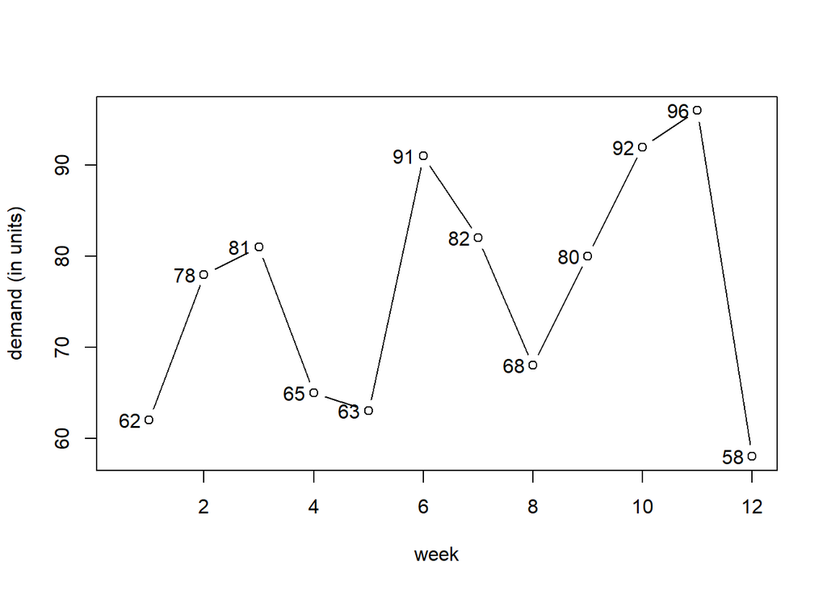

1. In first trial, the procurement manager intends to forecasts the demand of week 13 with simple moving average with $n=4$ week. Calculate the forecast of week 13 and forecast errors for the previous weeks. Add the forecasts to the diagram and calculate the root mean squared error (RMSE) for this forecasting method. (*10 points*)
2. The procurement manager perceives the RMSE of the simple moving average forecasts as too high. She tries to improve the forecasts by applying 2nd order exponential smoothing with $\alpha = 0.5$ and $\beta = 0.5$ as well as $a_0 = 60$ and $b_0=1$. Calculate the forecast for week 13 and the RMSE for this method. (*10 points*)
3. Do you think the procedure outlined in 2. is best suited for forecasting the time series? What could be done to find better forecasts? (*5 points*)

Hint: Round to 1 digit in all calculations of task 2.

# Task 3: ($s$,$q$) optimization

For raw material “R1” an ($s$,$q$) policy is pursued. The sole supplier charges 250 Euro for each order placed. The raw material has a unit price of 1.50 Euro and the “DeEffimero” calculates with a holding cost rate of 1% per Euro and week. The procurement manager remembers that the supplier is quite reliable and delivers orders 2 weeks once an order is placed. Additionally, she expects the weekly demand to be independent and normally distributed with $\mu=50$ and $\sigma=25$.

1. What is the risk period in this case? How is the demand in the risk period distributed? (*5 points*)
2. Calculate the optimal values of $s$ and $q$ when the procurement manager intends to achieve a $\beta$ service level of $98$%. (*15 points*)
3. How do you assess the appropriateness of the outlined procedure? What aspects could be reconsidered to improve the results? (*5 points*)

Hint: Use the following tabulated values of the standard normal distribution.

| $z$ | $\varphi(z)$ | $\Phi(z)$ | $L(Z,z)$ | $z$ | $\varphi(z)$ | $\Phi(z)$ | $L(Z,z)$ | $z$ | $\varphi(z)$ | $\Phi(z)$ | $L(Z,z)$ |
| --- | --- | --- | --- | --- | --- | --- | --- | --- | --- | --- | --- |
| -1.0000 | 0.2420 | 0.1587 | 1.0833 | -0.3243 | 0.3785 | 0.3728 | 0.5819 | 0.3514 | 0.3751 | 0.6373 | 0.2476 |
| -0.9730 | 0.2485 | 0.1653 | 1.0607 | -0.2973 | 0.3817 | 0.3831 | 0.5651 | 0.3784 | 0.3714 | 0.6474 | 0.2380 |
| -0.9459 | 0.2550 | 0.1721 | 1.0382 | -0.2703 | 0.3846 | 0.3935 | 0.5486 | 0.4054 | 0.3675 | 0.6574 | 0.2286 |
| -0.9189 | 0.2615 | 0.1791 | 1.0159 | -0.2432 | 0.3873 | 0.4039 | 0.5323 | 0.4324 | 0.3633 | 0.6673 | 0.2195 |
| -0.8919 | 0.2680 | 0.1862 | 0.9938 | -0.2162 | 0.3897 | 0.4144 | 0.5163 | 0.4595 | 0.3590 | 0.6770 | 0.2106 |
| -0.8649 | 0.2745 | 0.1936 | 0.9719 | -0.1892 | 0.3919 | 0.4250 | 0.5007 | 0.4865 | 0.3544 | 0.6867 | 0.2020 |
| -0.8378 | 0.2809 | 0.2011 | 0.9502 | -0.1622 | 0.3937 | 0.4356 | 0.4853 | 0.5135 | 0.3497 | 0.6962 | 0.1937 |
| -0.8108 | 0.2872 | 0.2087 | 0.9287 | -0.1351 | 0.3953 | 0.4463 | 0.4701 | 0.5405 | 0.3447 | 0.7056 | 0.1856 |
| -0.7838 | 0.2934 | 0.2166 | 0.9075 | -0.1081 | 0.3966 | 0.4570 | 0.4553 | 0.5676 | 0.3396 | 0.7148 | 0.1777 |
| -0.7568 | 0.2996 | 0.2246 | 0.8864 | -0.0811 | 0.3976 | 0.4677 | 0.4408 | 0.5946 | 0.3343 | 0.7239 | 0.1702 |
| -0.7297 | 0.3057 | 0.2328 | 0.8656 | -0.0541 | 0.3984 | 0.4784 | 0.4266 | 0.6216 | 0.3289 | 0.7329 | 0.1628 |
| -0.7027 | 0.3117 | 0.2411 | 0.8449 | -0.0270 | 0.3988 | 0.4892 | 0.4126 | 0.6486 | 0.3233 | 0.7417 | 0.1557 |
| -0.6757 | 0.3175 | 0.2496 | 0.8245 | 0.0000 | 0.3989 | 0.5000 | 0.3989 | 0.6757 | 0.3175 | 0.7504 | 0.1489 |
| -0.6486 | 0.3233 | 0.2583 | 0.8044 | 0.0270 | 0.3988 | 0.5108 | 0.3856 | 0.7027 | 0.3117 | 0.7589 | 0.1422 |
| -0.6216 | 0.3289 | 0.2671 | 0.7844 | 0.0541 | 0.3984 | 0.5216 | 0.3725 | 0.7297 | 0.3057 | 0.7672 | 0.1358 |
| -0.5946 | 0.3343 | 0.2761 | 0.7648 | 0.0811 | 0.3976 | 0.5323 | 0.3597 | 0.7568 | 0.2996 | 0.7754 | 0.1296 |
| -0.5676 | 0.3396 | 0.2852 | 0.7453 | 0.1081 | 0.3966 | 0.5430 | 0.3472 | 0.7838 | 0.2934 | 0.7834 | 0.1237 |
| -0.5405 | 0.3447 | 0.2944 | 0.7261 | 0.1351 | 0.3953 | 0.5537 | 0.3350 | 0.8108 | 0.2872 | 0.7913 | 0.1179 |
| -0.5135 | 0.3497 | 0.3038 | 0.7072 | 0.1622 | 0.3937 | 0.5644 | 0.3231 | 0.8378 | 0.2809 | 0.7989 | 0.1124 |
| -0.4865 | 0.3544 | 0.3133 | 0.6885 | 0.1892 | 0.3919 | 0.5750 | 0.3115 | 0.8649 | 0.2745 | 0.8064 | 0.1071 |
| -0.4595 | 0.3590 | 0.3230 | 0.6701 | 0.2162 | 0.3897 | 0.5856 | 0.3001 | 0.8919 | 0.2680 | 0.8138 | 0.1019 |
| -0.4324 | 0.3633 | 0.3327 | 0.6519 | 0.2432 | 0.3873 | 0.5961 | 0.2891 | 0.9189 | 0.2615 | 0.8209 | 0.0970 |
| -0.4054 | 0.3675 | 0.3426 | 0.6340 | 0.2703 | 0.3846 | 0.6065 | 0.2783 | 0.9459 | 0.2550 | 0.8279 | 0.0923 |
| -0.3784 | 0.3714 | 0.3526 | 0.6164 | 0.2973 | 0.3817 | 0.6169 | 0.2678 | 0.9730 | 0.2485 | 0.8347 | 0.0877 |
| -0.3514 | 0.3751 | 0.3627 | 0.5990 | 0.3243 | 0.3785 | 0.6272 | 0.2576 | 1.0000 | 0.2420 | 0.8413 | 0.0833 |

# Task 4: Joint Economic Lot Sizing

The components C1 to C6 are all produced on the same machine. The production manager thinks about switching to a make-to-stock production for these components due to the IT system break-down. The production-specific information are summarized as follows:

| component | C1 | C2 | C3 | C4 | C5 | C6 |
| --- | --- | --- | --- | --- | --- | --- |
| holding cost rate $c^{sh}_i$ | 0.01 | 0.05 | 0.1 | 0.25 | 0.02 | 0.08 |
| setup cost $c^{or}_i$ | 120 | 250 | 85 | 375 | 200 | 110 |
| demand rate $y_i$ | 70 | 25 | 55 | 30 | 95 | 100 |
| production rate $p_i$ | 400 | 300 | 380 | 350 | 650 | 500 |
| setup time $s_i$ | 0.2 | 0.5 | 0.3 | 0.1 | 0.2 | 0.1 |

1. Calculate the independent solution and the associated total cost. Is this solution feasible? (*10 points*)
2. Find a feasible solution with power-of-2 heuristic. What are the total cost of this solution? (*15 points*)